# **Chapter 9** Kinematic Chains I: Forward Kinematics

This chapter describes kinematic chains, and why they are important for studying human movement.

Specific concepts including: degrees of freedom (DOF), range of motion (ROM), and forward kinematics (FK) are described. These concepts are considered first in their original contexts (which include: Mechanical Engineering and Robotics), and then in the context of human movement control and human movement measurement.

- What is a kinematic chain?
- Degrees of freedom (DOF)
- Forward kinematics (FK)
- FK calculations
- Summary

# What is a kinematic chain?

Back to Table of Contents

- A kinematic chain is a sequence of bodies that are connected by joints
- Each joint permits motions in some directions and prevents motion in other directions
- Bodies in kinematic chains are often called "links"
- The links are usually rigid (i.e., they do not deform)
  - Bones can deform, but they are usually modeled as rigid
- For 2D (planar) kinematic chains, like those depicted in Fig.1, joints are usually hinge joints
  - Hinge joints allow relative rotation between adjacent links
  - Hinge joints do not allow relative displacement
- The posture of the planar kinematic chains depicted in Fig.1 is defined using:
  - The position of the first link ($r_x$, $r_y$)
  - The angles of all joints ($\phi_1$, $\phi_2$, $\phi_3$, ...)
- The links' motions are related in complex mechanical ways
  - The motion of one joint tends to trace a circle around that joint, which is relatively simple motion, but...
  - The motion of each joint generally affects the motion of all other joints
  - For example, acceleration at one joint causes all other joints to accelerate
  - Self experiment: hold your arm in a level, horizontal plane with your elbow at 90 deg, then rapidly extend your elbow; it is nearly impossible to move your elbow without also moving your shoulder
- The complex kinematic and dynamic behavior of kinematic chains is described in detail in Robotics textbooks

### Relevance to human movement:

- Human limbs (arms and legs) can be regarded as kinematic chains, similar to those depicted in Fig.1
- In fact, the entire human body is a kinematic chain:
  - Our pelvis can be regarded as the first link
  - Our vertebrae create joints with the pelvis, representing part of the kinematic chain
  - Our femurs create other joints with the pelvis, representing other parts of the kinematic chain
  - Extending from the vertebrae and femurs, we can trace through all joints and links in the human body
- Since Robotics describes the kinematics and dynamics of kinematic chains, it is very helpful to study Robotics when trying to understand human motion

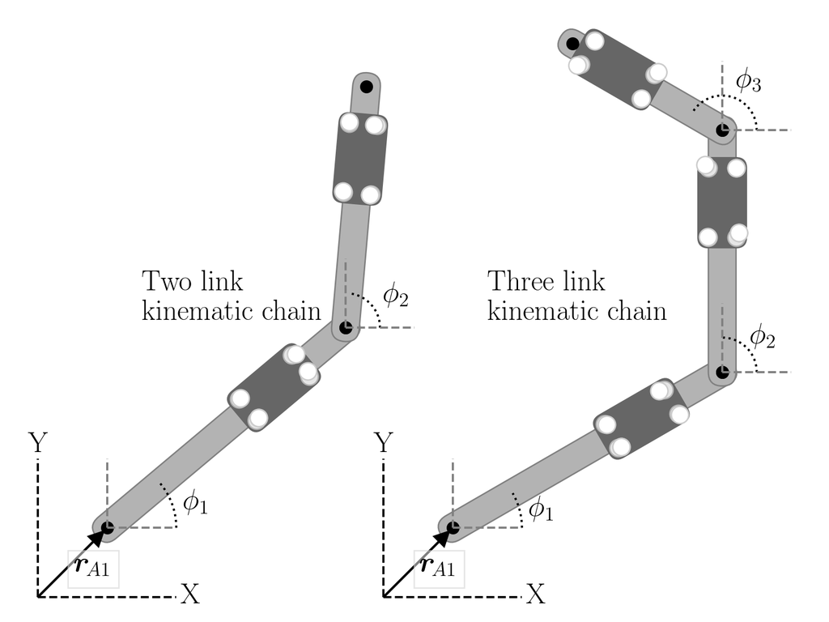

**Figure 1**. Example two-dimensional (planar) kinematic chains.

# Degrees of freedom (DOF)

Back to Table of Contents

- DOF, or more correctly: "kinematic DOF" represent one way to quantify the amount of motion that a kinematic chain can achieve
- DOF can be specified for single joints
  - For single joints, the DOF is A + B, where A is the number of orthogonal axes along which adjacent links can translate, and B is the number of orthogonal axes about which adjacent links can rotate
  - "Orthogonal" means "perpendicual", but "orthogonal" is usually used for many axes, and "perpendicular" is usually used for just two axes
  - The maximum number of DOF for a 2D joint is three: two translation, and one rotation
  - The maximum number of DOF for a 3D joint is six: three translation, and three rotation
- DOF can also be specified for whole kinematic chains
  - The number of DOFs for a whole kinematic chain is the total number of DOF from all joints
  - In Fig.1, the kinematic chain DOF values are 4 and 5 for the two- and three-link chains, respectively; there are 2 DOF for the proximal joint location, and one DOF for each joint.
- Hinge joints:
  - For 2D kinematic chains, hinge joints allow 1 DOF (rotation) and constrain two other DOFs (translation)
  - For 3D kinematic chains, hinge joints allow 1 DOF (rotation about one axis) and constrain five other DOFs (3 translation, 2 rotation)
- Many other types of joints exist, as depicted in Fig.2
  - One important type of joint is a ball-and-socket joint, which allows 3 rotational DOFs and zero translational DOFs.
- Joints limit DOF through physical contact: the geometric nature of the contacting surfaces determines the kinematic DOF
  - This raises a second important way to quantify kinematic chain motion: range of motion (ROM)
  - The range of motion (ROM) specifies the amount of joint motion along or about a specific axis
  - Ideal hinge joints have a ROM of zero in both translational directions
  - Ideal hinge joints can have an angular ROM of 360 deg

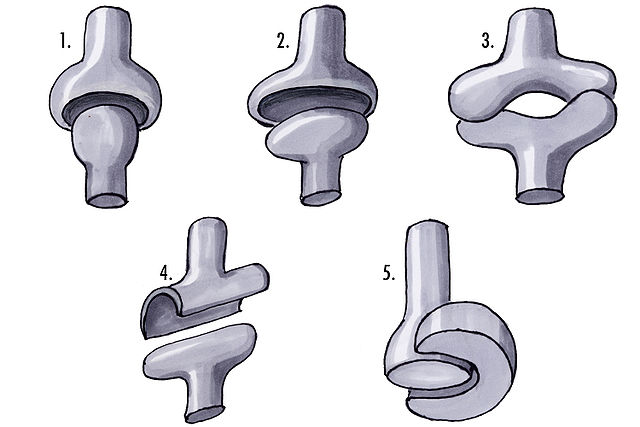

### Relevance to human movement:

- Joints in the human body are usually modeled using ideal mechanical joints like those depicted in Fig.2
  - Elbows and knees are often modeled as hinge joints
  - Shoulders and hips are often modeled as ball-and-socket joints
  - Joints in our wrists, hands, fingers, ankles, feet and toes are often modeled as saddle joints
- In reality, human joints are not ideal
  - All human joints (including knees and elbows) actually allow 6 DOF
  - The amount of motion may be different for different axes
  - Translational motion is usually limited to a few milimeters
- Just like ideal mechanical joints, DOF are limited by physical structures
  - In the human body, these structures include: cartilage and bone, ligaments, tendons and other soft tissues (e.g. skin)
  - These structures can only limit motion to a certain degree
- ROM is used to quantify the extent to which joint structures constrain motion
  - The knee joint has an angular ROM in the sagittal plane of approximately 140 deg
  - The knee joint has an angular ROM of just a few deg in other planes
  - The knee joint has transalations ROMs of just a few mm in all directions
- Many injuries occur at joints (e.g. ligament or tendon tears)
  - Understanding healthy joint behavior is important for understanding both injury mechanisms and rehabilitation
- DOF and ROM together quantify the amount of expected joint motion
- ROM can is positively affected by training and stretching, and is usually negatively affected by age
- ROM is often studies in different populations (e.g. baseball pitchers and other athletes, females vs. males, etc.)

# Forward kinematics (FK)

Back to Table of Contents

- "Forward kinematics" (FK) refers to the process of calculating **external coordinates** from **internal coordinates**
- This term comes from Robotics, and specifically from terminology pertaining to robotic manipulators (Fig.3)
  - For a robotic manipulator, the internal coordinates are joint angles: these are the coordinates that the robot directly controls
  - For a robotic manipulator, the most important external coordinates are the coordinates of the hand position, or "endpoint" position: these external coordinates are not directly controlled

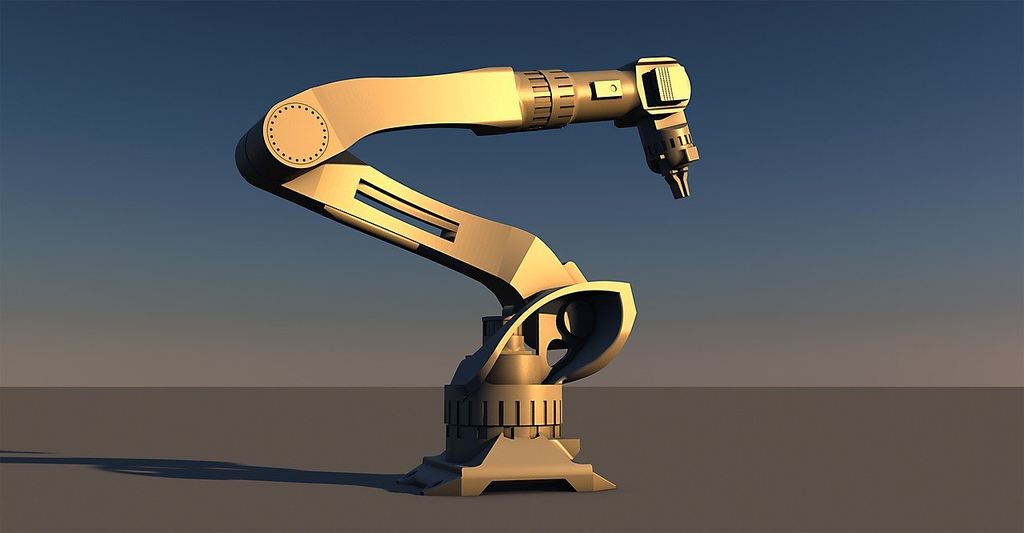

**Figure 3**. Example robotic manipulator.  
Image reproduced here under the Pixabay License. [Original source.](https://pixabay.com/illustrations/cybernetics-robot-robot-arm-1869205/)

- An example of a kinematic chain under forward kinematics control is shown in Video 1 below.
- For FK control, each joint angle is adjusted independently.

```python
from IPython.display import HTML

HTML("""
<center>
<video width="600" controls>
  <source src="video/fk.mp4" type="video/mp4">
</video>
<br>
<em><b>Video 1</b>. &nbsp; Example FK control of a kinematic chain. Video screencast produced in <a href="https://www.blender.org">Blender</a>.</em>
</center>
""")
```

[video not shown]

**Video 1**. Example FK control of a kinematic chain. Video screencast produced in [Blender](https://www.blender.org).

# FK Calculations

Back to Table of Contents

- FK calculations consist of calculating external coordinates (i.e., XYZ positions) from known internal coordinates (i.e., joint angles)
- FK calculations are generally easy
- Consider the planar 3-link kinematic chain in Fig.4 below.
  - The $\phi$ variables represent joint angles
  - The $L$ variables represent link lengths (i.e., inter-joint distances)
  - For this kinematic chain, one FK goal is to calculate the XY position of point D, given the joint angles
  - This FK solution is shown below.

\begin{align} \begin{pmatrix}x_A\\y_A\end{pmatrix} &= \begin{pmatrix}r_x\\r_y\end{pmatrix} \\ \\ \begin{pmatrix}x_B\\y_B\end{pmatrix} &= \begin{pmatrix}x_A + L_1\cos\phi_1 \\ y_A + L_1\sin\phi_1 \end{pmatrix} \\ \\ \begin{pmatrix}x_C\\y_C\end{pmatrix} &= \begin{pmatrix}x_B + L_2\cos(\phi_1 + \phi_2) \\ y_B + L_2\sin(\phi_1 + \phi_2) \end{pmatrix} \\ \\ \begin{pmatrix}x_D\\y_D\end{pmatrix} &= \begin{pmatrix}x_C + L_3\cos(\phi_1 + \phi_2 + \phi_3) \\ y_C + L_3\sin(\phi_1 + \phi_2 + \phi_3) \end{pmatrix} \\ \end{align}

Note that the FK solution is simple: it is a sequential calculation of progressively distal joint locations.

Using the link length and joint angle values indicacted in Fig.4, we obtain the following FK solution:

\begin{align} \begin{pmatrix}x_D\\y_D\end{pmatrix} &= \begin{pmatrix}24.8\\68.0\end{pmatrix} \\ \\ \end{align}

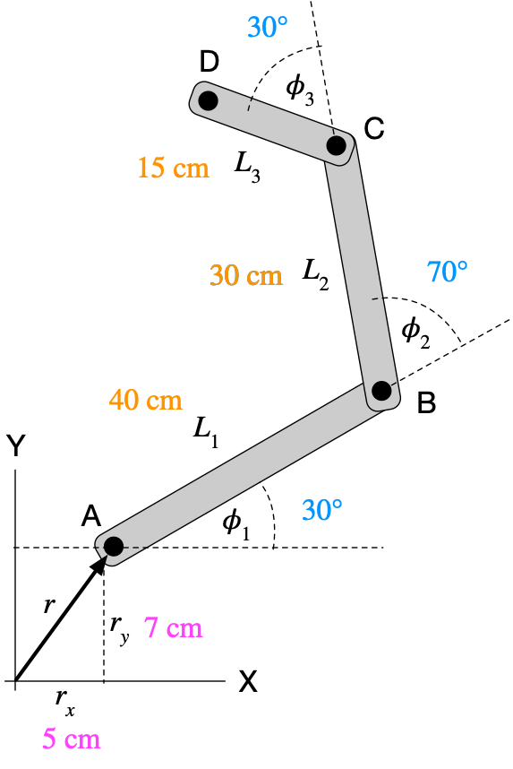

# Summary

Back to Table of Contents

- This chapter discussed kinematic chains and how they relate to human movement
- Kinematic chain mobility can be quantified using degrees of freedom and range of motion
- "Degrees of freedom" refers to the number of orthogonal axes along which or about which a link can translate or rotate
- "Range of motion" refers to the linear or angular displacement that each joint permits
- Ideal mechanical joints permit motion only for a small number of DOF
- Human joints are non-ideal, and all human joints permit 6 DOF of motion (although the ROM in some directions may be small)
- Forward kinematics refers to calcualting external coordinates (XYZ positions) from known internal coordinates (joint angles)
- The forward kinematics problem is very easy for simple kinematic chains